# Similarity Metric Distributions

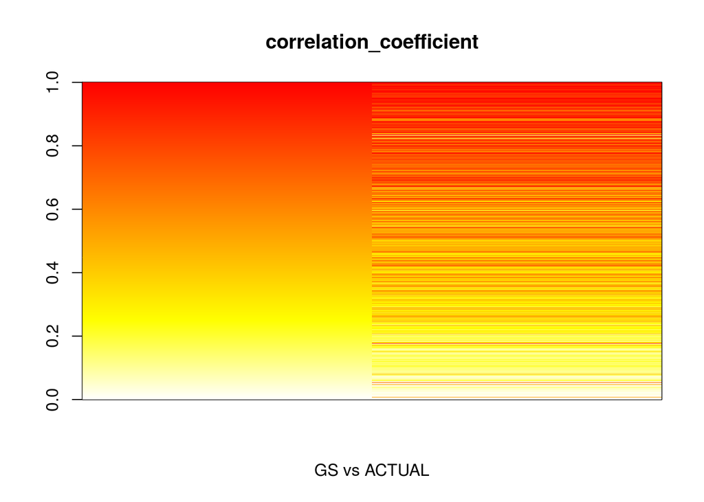

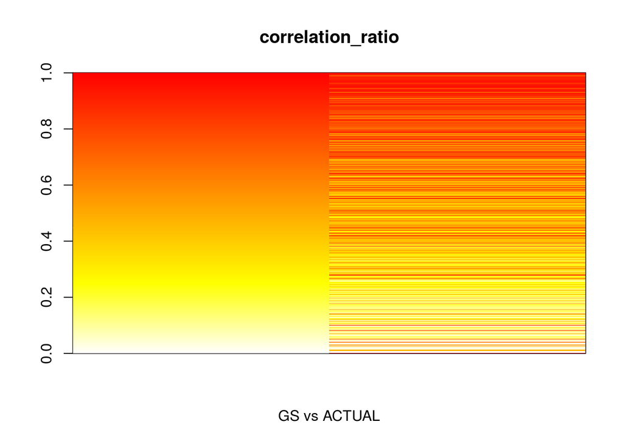

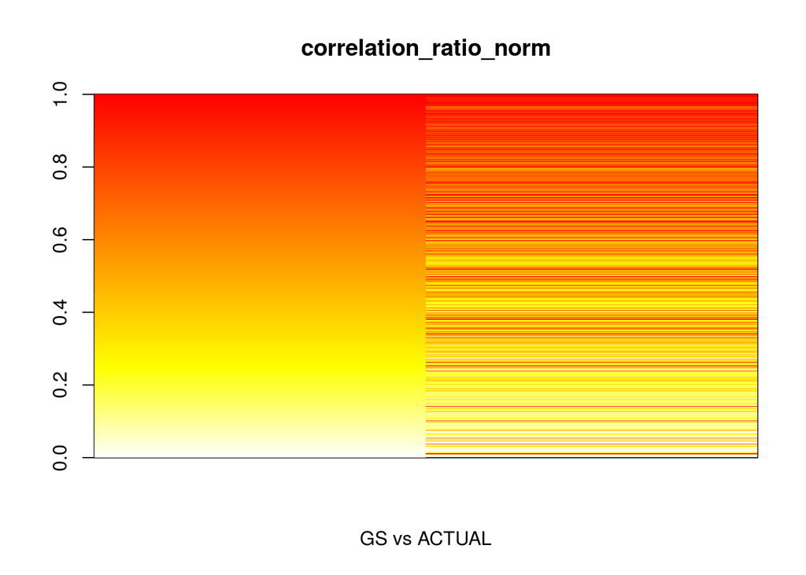

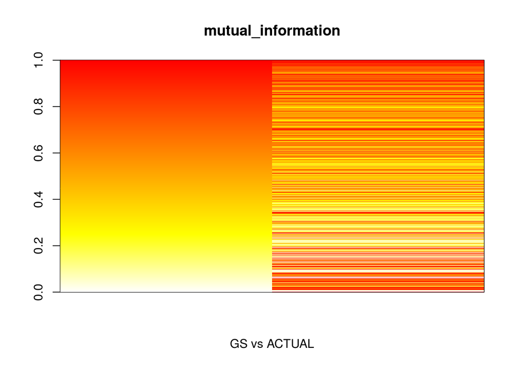

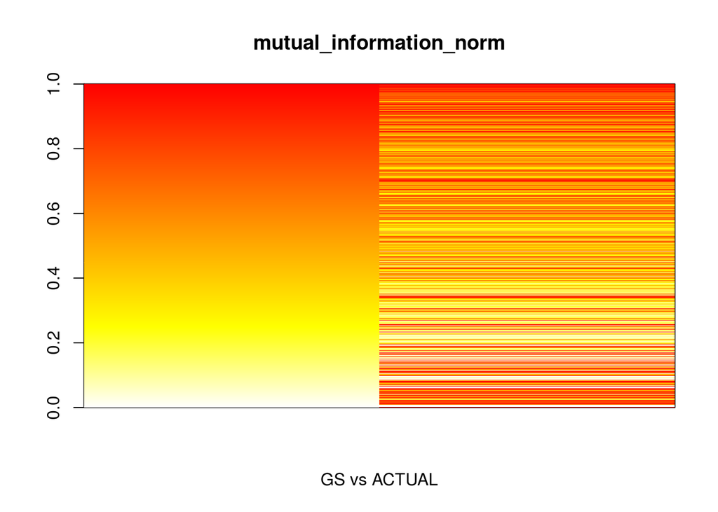

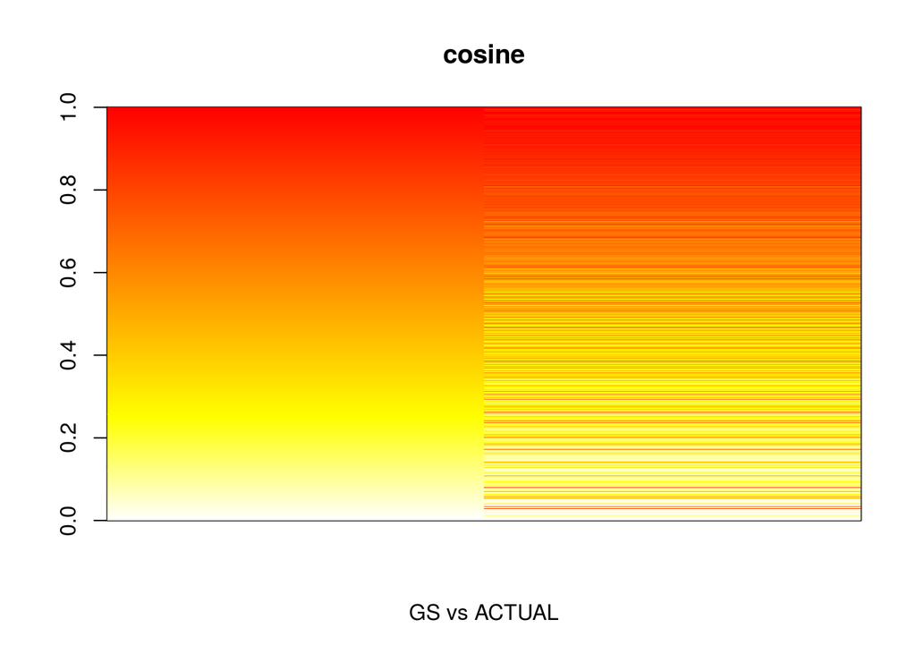

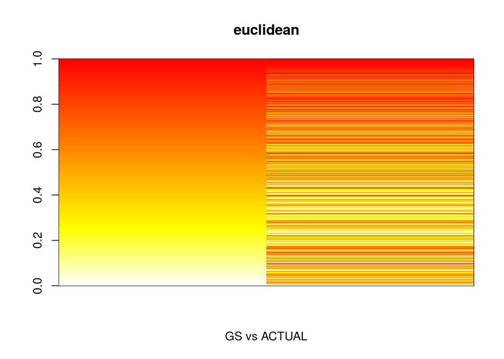

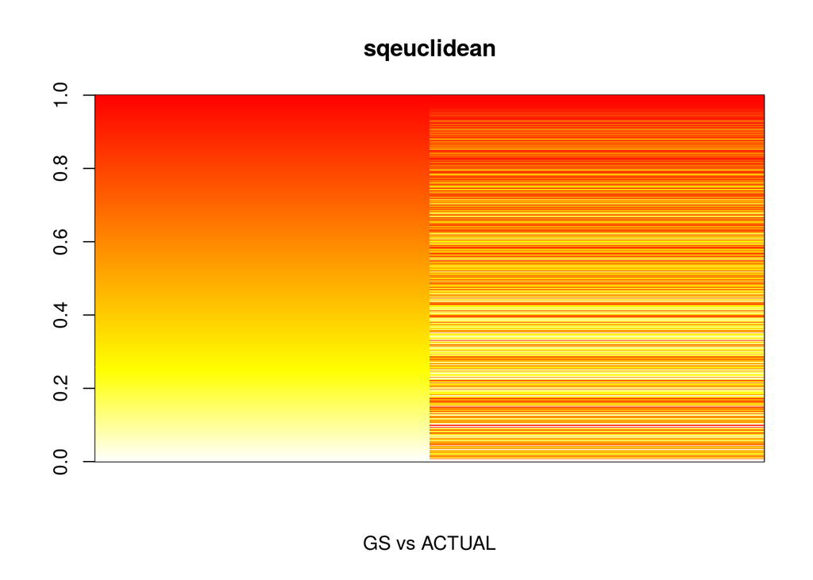

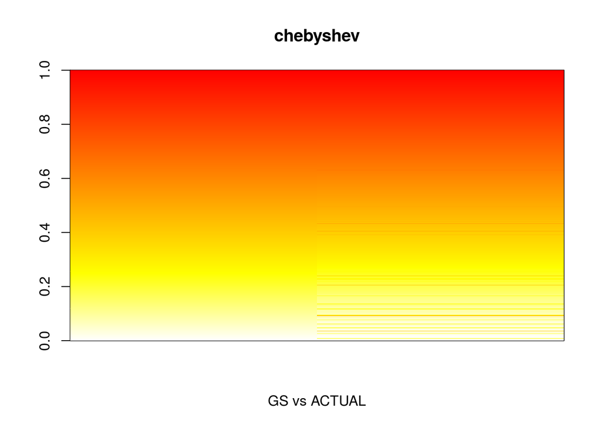

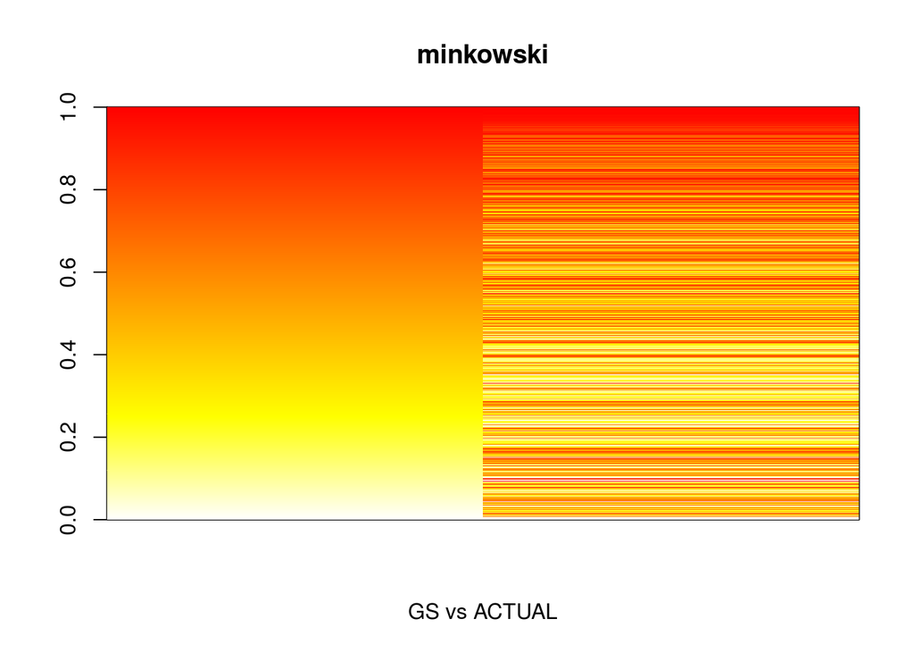

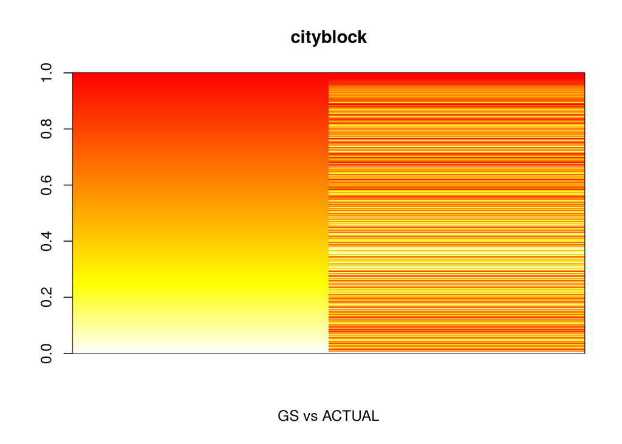

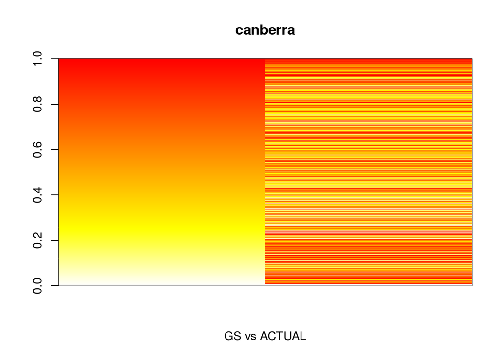

[1 more figures not shown]

```r
metric_names = names(gs)

for (m in metric_names){
  gold_standard = gs[[m]]
  actual_order = metrics_sorted[[m]]
  colors = rev(heat.colors(length(gold_standard)))
  idx = match(names(actual_order),names(gold_standard))
  actual_order = gold_standard[idx]
  data = rbind(gold_standard,actual_order)
  rownames(data) = c("GS","ACTUAL")
  image(data,xaxt="n",col=colors,main=m,xlab=c("GS vs ACTUAL"))
}
```

Now let’s write a super simple scoring function - we want to know the average displacement that we are off. I can imagine doing this in different ways - perhaps adding weights to be less severe if images move around within the same openfmri study, or taking thresholding into account. This error function is very important because it must reflect the goals of the researcher, which may be to find similar studies, or to disregard study and only return the most similar images across all of them.

```r
calculate_average_error = function(gold_standard,actual_order){
  return(sum(abs(gold_standard - actual_order))/length(actual_order))
}

errors = c()
for (m in metric_names){
  gold_standard = gs[[m]]
  actual_order = metrics_sorted[[m]]
  colors = rev(heat.colors(length(gold_standard)))
  idx = match(names(actual_order),names(gold_standard))
  actual_order = gold_standard[idx]
  error = calculate_average_error(gold_standard,actual_order)
  cat(m,": ",error,"\n",sep="")
  errors[m] = error
}
```

```
## correlation_coefficient: 223.4902
## correlation_ratio: 268.7337
## correlation_ratio_norm: 326.0805
## mutual_information: 573.0389
## mutual_information_norm: 573.0389
## cosine: 185.7089
## euclidean: 473.4213
## sqeuclidean: 473.4213
## chebyshev: 33.63287
## minkowski: 473.4213
## cityblock: 622.4187
## canberra: 744.9423
## braycurtis: 230.2308
```

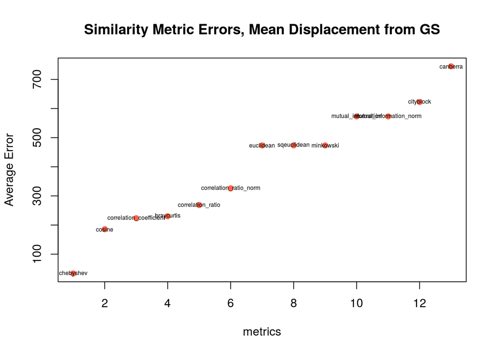

```r
plot(sort(errors),pch=19,col="tomato",ylab="Average Error",xlab="metrics",main="Similarity Metric Errors, Mean Displacement from GS")
text(sort(errors),names(sort(errors)),cex=.5)
```

Wow, not what I expected. I haven’t checked this over in detail yet because I need to work on a presentation for a few hours. First, we can throw away chebyshev because its a maximum distance, so in any case (including the gold standard) it will return the maximum distance between the two vectors. So image A vs image B at any other threshold is likely to return the same thing as long as a highly different voxel is still in the mask.

I’m not surprised that standard distance metrics (euclidean, manhatten, etc) are rather bad. We could see this looking at the distributions even before calculating error. I am, however, pretty surprised by mutual information, which does a pretty good job registering images, but (according to this analysis) can get rather mixed up when the images are thresholded. I would hypothesize that it has something to do with the smaller set of values in that other images get moved up in the list simply because the distributions can be better matched. Again, this would need testing!

The Braycurtis is the sum of the differences of the vectors divided by the sum of the added vectors. I need to think about this one too. Actually, I need to synthesize all of these - today my goal was just to start doing some basic visualization of these metrics for one unthresholded image, 134! :)

### Next steps

I need to make my presentation first, but next I’d like to assess the orderings based on images in the same study, and the level of thresholding. I think we might see patterns related to study, and to the level of thresholding. Stay tuned!